# Updating Riginos Analysis

Carmen Ebel

7/6/2021

## Need the Relative Cover of Each species

# Principal Response Curve Analysis

## PRC/RDA Analysis w/all sampling points (bi-annual for first part of time series) (RELATIVE COVER)

### Create Reference Treatment

### PRC with 1999-2020 Data

```r
#1 add reference point as a new sampling point to species data
relcovprc_all_bi <- rbind(klee_rel_all, refyear_all) %>%
  pivot_wider(names_from = "SPECIES", values_from = "relcov") %>%
  mutate(TREATMENT = fct_relevel(TREATMENT, "REF", "O", "W", "MW", "C", "WC", "MWC"))
## important that REF is ordered first so that it becomes the comparison

relcovprc_all_bi[is.na(relcovprc_all_bi)] <- 0 ## replace NA values with 0

## create vectors of the year and treatment
year_all <- as.factor(relcovprc_all_bi$Date_numeric)
TRT_all <- as.factor(relcovprc_all_bi$TREATMENT)

## remove the non-species columns
sp_only_all_bi <- relcovprc_all_bi %>%
  ungroup() %>%
  select(!(1:6))

## Principal Response Curve Analysis
prc_relcov_all_bi <- prc(response = sp_only_all_bi, treatment = TRT_all, time = year_all)

prc_relcov_all_bi ## RDA
```

```
## Call: prc(response = sp_only_all_bi, treatment = TRT_all, time =
## year_all)
##
##                 Inertia Proportion Rank
## Total         0.0141689  1.0000000
## Conditional   0.0001267  0.0089432   33
## Constrained   0.0001534  0.0108258   22
## Unconstrained 0.0138885  0.9802142   67
## Inertia is variance
##
## Eigenvalues for constrained axes:
##      RDA1      RDA2      RDA3      RDA4      RDA5      RDA6      RDA7      RDA8
## 9.915e-05 2.199e-05 1.802e-05 5.330e-06 3.660e-06 2.370e-06 1.450e-06 3.700e-07
##      RDA9     RDA10     RDA11     RDA12     RDA13     RDA14     RDA15     RDA16
## 2.500e-07 1.900e-07 1.200e-07 9.000e-08 7.000e-08 6.000e-08 6.000e-08 5.000e-08
##     RDA17     RDA18     RDA19     RDA20     RDA21     RDA22
## 4.000e-08 3.000e-08 3.000e-08 3.000e-08 2.000e-08 2.000e-08
##
## Eigenvalues for unconstrained axes:
##      PC1      PC2      PC3      PC4      PC5      PC6      PC7      PC8
## 0.005659 0.003334 0.002602 0.000908 0.000802 0.000215 0.000185 0.000062
## (Showing 8 of 67 unconstrained eigenvalues)
```

```r
summary(prc_relcov_all_bi) ## PRC
```

```
##
## Call:
## prc(response = sp_only_all_bi, treatment = TRT_all, time = year_all)
## Species scores:
##            Acalypha_crenata                Aerva_lanata
##                  -5.780e-04                   5.227e-03
##         Amaranthus_hibridus           Aristida_congesta
##                  -3.792e-04                  -2.350e-05
##          Aristida_kenyensis           Aspilia_pluriseta
##                  -2.269e-03                   4.259e-02
##         Asterolinon_adoense      Bothriochloa_insculpta
##                  -3.391e-05                  -5.504e-02
##                Brachiaria_3      Brachiaria_eruciformis
##                  -1.069e-03                  -7.134e-03
##       Brachiaria_lachnantha        Caralluma_acutangula
##                  -8.809e-01                  -2.018e-04
##     Chenopodium_opulifolium   Chenopodium_schraderianum
##                  -6.876e-05                  -9.335e-05
##                  Chloris_sp               Commelina_spp
##                  -1.151e-05                  -7.112e-04
##    Commicarpus_pedunculosus                   Conyza_sp
##                  -5.731e-04                   4.881e-03
##                Corchorus_sp               Crotalaria_sp
##                  -1.073e-04                  -5.304e-05
##        Cyathula_orthacantha            Cynodon_dactylon
##                  -1.032e-04                  -1.183e-03
##      Cynodon_plectostachyus        Cyperus_Mariscus_spp
##                  -2.593e-04                  -1.051e-02
##                 Digitaria_2        Digitaria_milanjiana
##                  -1.782e-02                  -1.329e-03
##          Dinebra_retroflexa         Dyscoriste_radicans
##                  -2.154e-03                   1.867e-02
##              Eragrostis_spp     Euphorbia_inaequilatera
##                   3.656e-03                   4.855e-06
##        Evolvulus_alsinoides                        Fern
##                  -5.642e-04                   1.348e-05
##              Gutenbergia_sp         Harpachne_schimperi
##                  -3.949e-04                   8.111e-06
##           Hermannia_uhligii        Hibiscus_flavifolius
##                   2.664e-05                   1.706e-03
```

[output cut: 78 more lines]

```
## MWC -0.04143 -0.02881 -0.03984 -0.04008 -0.03779 -0.03765 -0.04015 -0.01394
##     20100601 20110601 20120601 20130601 20140601 20150601 20160601 20170601
## O   -0.05896 -0.06962 -0.06319 -0.04673 -0.06371 -0.05103 -0.05897 -0.07629
## W   -0.04396 -0.05561 -0.04465 -0.03950 -0.06219 -0.05125 -0.05346 -0.08632
## MW  -0.04237 -0.05853 -0.03434 -0.04068 -0.04972 -0.05091 -0.05972 -0.08507
## C   -0.03779 -0.04538 -0.03727 -0.03558 -0.05165 -0.05127 -0.05811 -0.07920
## WC  -0.01845 -0.02163 -0.02351 -0.02489 -0.04546 -0.03585 -0.04249 -0.05436
## MWC -0.01410 -0.02197 -0.01517 -0.01661 -0.02487 -0.02444 -0.03041 -0.05461
##     20180601 20190601 20200601
## O   -0.07176 -0.06853 -0.05618
## W   -0.06438 -0.07199 -0.05478
## MW  -0.05557 -0.07843 -0.05338
## C   -0.06569 -0.08167 -0.05047
## WC  -0.04806 -0.05723 -0.04966
## MWC -0.03139 -0.04471 -0.04685
```

## Testing & Extracting Results

## One way to visualize the PRC

plot(prc_relcov_all_bi)

abundance <- colSums(sp_only_all_bi) ## add up (by column) the abundances of the original matrix plot(prc_relcov_all_bi, select = abundance > 5) # the 5 indicates that only species with >5 total abundance are plotted #The species weights are the correlation with the treatment effects. #The higher the (abs value) weight, the more the #actual response pattern of the species is likely to follow the #pattern in the PRC.

prc_relcov_all_bi #prc is special case of model: rda(response~treatment*time+Condition(time)) ## conditional explains 0.89 % of the variation ## treatment and its interaction with time (constrained) explains 1.08% of the variation

prc_relcov_all_bi$CCA$eig/sum(prc_relcov_all_bi$CCA$eig) ## first axis explains 64.64% of variance ## second axis explains 14.33% of variance

anova(prc_relcov_all_bi) ## overall model significance (uses vegan’s anova.cca function) anova(prc_relcov_all_bi, strata = Date_final, first = TRUE, perm.max = 9999) anova(prc_relcov_all_bi, by = “terms”, permu = 100) ## treatment significance and interaction significance

## monte carlo permutation test for treatment differences within time periods; sequential

Ftests<-NULL for (i in levels(month )){ timeper<-kv8[month ==i,] trt<-treatment[month ==i] Ftests [[i]] <- anova(rda(timeper ~ trt), by = “terms”, step =1000) }

Ftests sapply (Ftests, function(x) x[1,5])#extracts pvalues for each date.

#month effects within treatment Ftests2<-NULL for (i in levels(treatment )){ trt2<-kv8[treatment==i,] timeper2<-month[treatment ==i] Ftests2 [[i]] <- anova(rda(trt2 ~ timeper2), by = “terms”, step =1000) }

Ftests2 sapply (Ftests2, function(x) x[1,5])

# loop through time, compute PCA, extract scores and do Dunnett-Test

for (i in levels(week)) { # PCA take_spec <- pyrifos[week == i, ] pca <- rda(take_spec) # scores of first principal component pca_scores <- scores(pca, display = “sites”, choices = 1, scaling = 1) mod_aov <- aov(pca_scores ~ dose, data = df[week == i, ]) out[[i]] <- summary(glht(mod_aov, alternative = “t”, linfct = mcp(dose = “Dunnett”))) }

## extract scores

prc_scores <- scores(prc_relcov_all_bi, c(1:10), scaling = 3)

site_scores <- data.frame(sites = prc_scores$sites)

```r
prcsum_relcov_all_bi <- summary(prc_relcov_all_bi, scaling = 1) ## save the summary of the PRC analysis

prcsum_relcov_all_bi
```

```
##
## Call:
## prc(response = sp_only_all_bi, treatment = TRT_all, time = year_all)
## Species scores:
##            Acalypha_crenata                Aerva_lanata
##                  -1.998e-03                   1.807e-02
##         Amaranthus_hibridus           Aristida_congesta
##                  -1.311e-03                  -8.124e-05
##          Aristida_kenyensis           Aspilia_pluriseta
##                  -7.846e-03                   1.473e-01
##         Asterolinon_adoense      Bothriochloa_insculpta
##                  -1.173e-04                  -1.903e-01
##                Brachiaria_3      Brachiaria_eruciformis
##                  -3.696e-03                  -2.466e-02
##       Brachiaria_lachnantha        Caralluma_acutangula
##                  -3.046e+00                  -6.979e-04
##     Chenopodium_opulifolium   Chenopodium_schraderianum
##                  -2.377e-04                  -3.228e-04
##                  Chloris_sp               Commelina_spp
##                  -3.980e-05                  -2.459e-03
##    Commicarpus_pedunculosus                   Conyza_sp
##                  -1.982e-03                   1.688e-02
##                Corchorus_sp               Crotalaria_sp
##                  -3.710e-04                  -1.834e-04
##        Cyathula_orthacantha            Cynodon_dactylon
##                  -3.567e-04                  -4.090e-03
##      Cynodon_plectostachyus        Cyperus_Mariscus_spp
##                  -8.964e-04                  -3.633e-02
##                 Digitaria_2        Digitaria_milanjiana
##                  -6.162e-02                  -4.595e-03
##          Dinebra_retroflexa         Dyscoriste_radicans
##                  -7.446e-03                   6.455e-02
##              Eragrostis_spp     Euphorbia_inaequilatera
##                   1.264e-02                   1.679e-05
##        Evolvulus_alsinoides                        Fern
##                  -1.951e-03                   4.660e-05
##              Gutenbergia_sp         Harpachne_schimperi
##                  -1.365e-03                   2.804e-05
##           Hermannia_uhligii        Hibiscus_flavifolius
##                   9.212e-05                   5.899e-03
```

[output cut: 78 more lines]

```
## MWC -0.01135 -0.01198 -0.008334 -0.011524 -0.01159 -0.01093 -0.01089 -0.01161
##      20100101  20100601  20110601  20120601  20130601  20140601  20150601
## O   -0.019925 -0.017053 -0.020135 -0.018275 -0.013517 -0.018428 -0.014761
## W   -0.011596 -0.012713 -0.016084 -0.012914 -0.011425 -0.017986 -0.014824
## MW  -0.014940 -0.012254 -0.016929 -0.009933 -0.011766 -0.014379 -0.014725
## C   -0.011334 -0.010929 -0.013125 -0.010779 -0.010290 -0.014938 -0.014829
## WC  -0.007357 -0.005335 -0.006255 -0.006800 -0.007200 -0.013149 -0.010370
## MWC -0.004031 -0.004077 -0.006355 -0.004387 -0.004804 -0.007193 -0.007067
##      20160601 20170601  20180601 20190601 20200601
## O   -0.017056 -0.02207 -0.020754 -0.01982 -0.01625
## W   -0.015462 -0.02497 -0.018620 -0.02082 -0.01584
## MW  -0.017274 -0.02461 -0.016072 -0.02269 -0.01544
## C   -0.016806 -0.02291 -0.018999 -0.02362 -0.01460
## WC  -0.012288 -0.01572 -0.013899 -0.01655 -0.01436
## MWC -0.008794 -0.01579 -0.009079 -0.01293 -0.01355
```

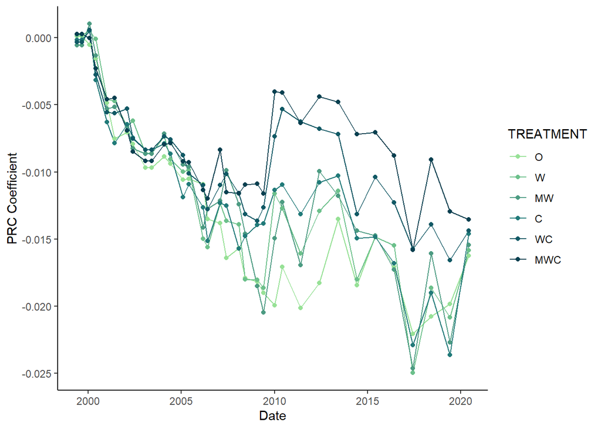

```r
prc_relresults_all_bi <- data.frame(coeff = prcsum_relcov_all_bi$coefficients) %>% ## add the coefficients to a dataframe
  rownames_to_column("TREATMENT") %>%
  pivot_longer(cols = 2:35, names_to = "year", values_to = "coeff") %>%
  mutate(Date_numeric = str_remove(year, "coeff."), Date_final = ymd(Date_numeric)) %>%
  select(!year) %>%
  mutate(TREATMENT = fct_relevel(TREATMENT, "O", "W", "MW", "C", "WC", "MWC")) #%>%
  #mutate(coeff = coeff*(-1))

prc_relresults_all_bi$TREATMENT <- as.factor(prc_relresults_all_bi$TREATMENT)

## plot coefficients over time
ggplot(prc_relresults_all_bi, aes(x=Date_final, y=coeff, color = TREATMENT)) +
  geom_line() +
  geom_point() +
  scale_color_manual(values = green_scale) +
  xlab("Date") + ylab("PRC Coefficient")
```

## Breakpoint Analysis of PRC Results

## Visualize the PRC Results

```
## # A tibble: 11 x 8
##     Year meanppt SEppt season condition month   day Date_final
##    <int>   <dbl> <dbl> <chr>  <chr>     <chr> <dbl> <date>
##  1  1999    27.4  9.35 sepdec dry       Jan      15 1999-01-15
##  2  2000    21.7  4.11 sepdec dry       Jan      15 2000-01-15
##  3  2007    27.6 14.8  sepdec dry       Jan      15 2007-01-15
##  4  2010    15.3  8.45 sepdec dry       Jan      15 2010-01-15
##  5  2016    14.8 14.8  sepdec dry       Jan      15 2016-01-15
##  6  1999    26.0 13.1  febmay dry       Jun      15 1999-06-15
##  7  2000    14.2  6.00 febmay dry       Jun      15 2000-06-15
##  8  2007    25.6 13.0  febmay dry       Jun      15 2007-06-15
##  9  2009    19.9 15.1  febmay dry       Jun      15 2009-06-15
## 10  2014    33.9 19.6  febmay dry       Jun      15 2014-06-15
## 11  2017    22.7  9.40 febmay dry       Jun      15 2017-06-15
```

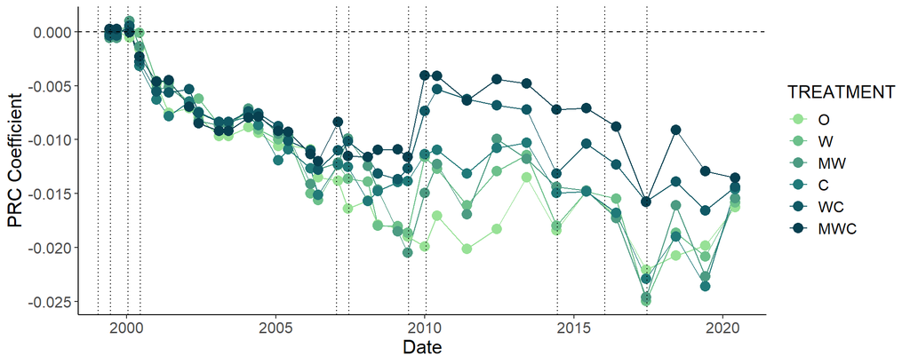

## Classifying Precipitation Events

## DEFINING DRY AND WET PERIODS

## from Riginos 2018: Drought = rainfall in the bottom 25th percentile of all sample periods; less than 120 mm in the four-month rainy season preceding sampling

## need total rainfall in each month? have the average of the three blocks,

## so if I add the averages of the last four months that should give the correct definition of drought

## need to sum precipitation

## September PPT

sepdec <- ppt99_20 %>% filter(Date_final %like% “-09” | Date_final %like% “-10” | Date_final %like% “-11” | Date_final %like% “-12”) %>% group_by(Year) %>% summarize(mo4ppt = sum(Average)) %>% mutate(season = “sepdec”)

## February to May

febmay <- ppt99_20 %>% filter(Date_final %like% “-02”| Date_final %like% “-03” | Date_final %like% “-04” | Date_final %like% “-05”) %>% group_by(Year) %>% summarize(mo4ppt = sum(Average)) %>% mutate(season = “febmay”)

## Calculate the 25th percentile for precipitation to identify dry events

drysepdec <- sepdec %>% filter(mo4ppt < quantile(sepdec$mo4ppt, probs = .25, na.rm = TRUE) | mo4ppt < 120) %>% mutate(condition = “dry”)

dryfebmay <- febmay %>% filter(mo4ppt < quantile(febmay$mo4ppt, probs = .25, na.rm = TRUE)| mo4ppt < 120) %>% mutate(condition = “dry”)

### PRC with 1999-2013 Data

```r
## TRYING PRC WITH UP TO 2013 DATA; NOT LOG TRANSFORMED----
#1 add reference point as a new sampling point to species data
relcovprc_bi <- rbind(klee_rel_all, refyear_all) %>%
  pivot_wider(names_from = "SPECIES", values_from = "relcov") %>%
  mutate(TREATMENT = fct_relevel(TREATMENT, "REF", "O", "W", "MW", "C", "WC", "MWC")) %>%
  filter(Date_numeric < 20140601)
## important that REF is ordered first so that it becomes the comparison

relcovprc_bi[is.na(relcovprc_bi)] <- 0 ## replace NA values with 0

## create vectors of the year and treatment
year <- as.factor(relcovprc_bi$Date_numeric)
TRT <- as.factor(relcovprc_bi$TREATMENT)

## remove the non-species columns
sp_only_bi <- relcovprc_bi %>%
  ungroup() %>%
  select(!(1:6))

## Principal Response Curve Analysis
prc_relcov_bi <- prc(response = sp_only_bi, treatment = TRT, time = year)
summary(prc_relcov_bi)
```

```
##
## Call:
## prc(response = sp_only_bi, treatment = TRT, time = year)
## Species scores:
##            Acalypha_crenata                Aerva_lanata
##                  -6.797e-04                   5.712e-03
##         Amaranthus_hibridus           Aristida_congesta
##                  -1.357e-04                  -2.963e-05
##          Aristida_kenyensis           Aspilia_pluriseta
##                  -2.084e-03                   3.379e-02
##         Asterolinon_adoense      Bothriochloa_insculpta
##                  -4.629e-06                  -4.167e-02
##                Brachiaria_3      Brachiaria_eruciformis
##                  -1.037e-03                  -9.144e-03
##       Brachiaria_lachnantha        Caralluma_acutangula
##                  -7.111e-01                  -2.155e-04
##     Chenopodium_opulifolium   Chenopodium_schraderianum
##                  -9.022e-05                  -1.010e-04
##                  Chloris_sp               Commelina_spp
##                   3.565e-05                  -1.588e-03
##    Commicarpus_pedunculosus                   Conyza_sp
##                  -6.903e-04                   4.962e-03
##                Corchorus_sp               Crotalaria_sp
##                  -1.942e-04                   1.603e-05
##        Cyathula_orthacantha            Cynodon_dactylon
##                  -1.339e-04                  -8.933e-04
##      Cynodon_plectostachyus        Cyperus_Mariscus_spp
##                  -1.865e-04                  -1.079e-02
##                 Digitaria_2        Digitaria_milanjiana
##                  -1.330e-02                  -2.410e-03
##          Dinebra_retroflexa         Dyscoriste_radicans
##                  -2.609e-03                   1.701e-02
##              Eragrostis_spp     Euphorbia_inaequilatera
##                   2.232e-03                  -2.244e-05
##        Evolvulus_alsinoides                        Fern
##                  -6.959e-04                   1.420e-04
##              Gutenbergia_sp         Harpachne_schimperi
##                  -3.950e-04                   1.010e-05
##           Hermannia_uhligii        Hibiscus_flavifolius
##                   3.860e-05                   1.650e-03
```

[output cut: 71 more lines]

```
## MWC -0.03622 -0.04014 -0.04014 -0.03406 -0.03175 -0.03806 -0.03832 -0.04955
##     20060601 20070201 20070601 20080201 20080601 20090201 20090601 20100101
## O   -0.05906 -0.05625 -0.06687 -0.06487 -0.07445 -0.07455 -0.07746 -0.08032
## W   -0.06967 -0.05250 -0.05976 -0.06140 -0.07872 -0.07576 -0.07844 -0.04740
## MW  -0.05640 -0.05066 -0.04275 -0.05189 -0.06246 -0.07475 -0.08634 -0.06236
## C   -0.06968 -0.05376 -0.05646 -0.07164 -0.06581 -0.06112 -0.06441 -0.04990
## WC  -0.05892 -0.04696 -0.04768 -0.05184 -0.05908 -0.05677 -0.05430 -0.03166
## MWC -0.05231 -0.03466 -0.04820 -0.04830 -0.04798 -0.04395 -0.04831 -0.01661
##     20100601 20110601 20120601 20130601
## O   -0.06921 -0.07931 -0.07108 -0.05226
## W   -0.04964 -0.06363 -0.04973 -0.04417
## MW  -0.04777 -0.06436 -0.03709 -0.04533
## C   -0.04578 -0.05217 -0.04135 -0.03945
## WC  -0.01984 -0.02475 -0.02509 -0.02734
## MWC -0.01668 -0.02617 -0.01742 -0.01603
```

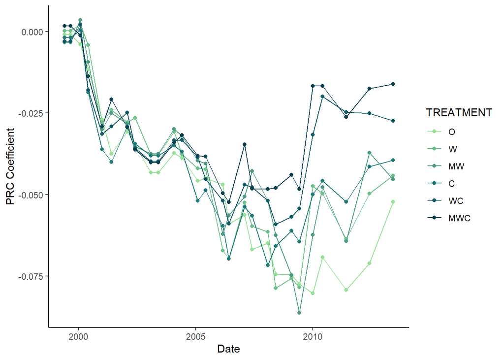

```r
prcsum_relcov_bi <- summary(prc_relcov_bi) ## save the summary of the PRC analysis

prc_relresults_bi <- data.frame(coeff = prcsum_relcov_bi$coefficients) %>% ## add the coefficients to a dataframe
  rownames_to_column("TREATMENT") %>%
  pivot_longer(cols = 2:28, names_to = "year", values_to = "coeff") %>%
  mutate(Date_numeric = str_remove(year, "coeff."), Date_final = ymd(Date_numeric)) %>%
  select(!year) %>%
  mutate(TREATMENT = fct_relevel(TREATMENT, "O", "W", "MW", "C", "WC", "MWC"))# %>%
 # mutate(coeff = coeff*(-100))

prc_relresults_bi$TREATMENT <- as.factor(prc_relresults_bi$TREATMENT)

## plot coefficients over time
ggplot(prc_relresults_bi, aes(x=Date_final, y=coeff, color = TREATMENT)) +
  geom_line() +
  geom_point() +
  scale_color_manual(values = green_scale) +
  xlab("Date") + ylab("PRC Coefficient")
```